# Quantitative Genomics and Genetics 2019

Computer Lab 4

Scott Kulm

2/19/2019

### 1. Boolean Data Type

- Boolean data type is a data type with only two possible values, TRUE and FALSE.
- Its main usage is for testing conditions.
- In R and many other languages, the actual values for TRUE and FALSE are 1 and 0.
- This can be illustrated as follows

```r
sum(TRUE + TRUE)
```

```
[1] 2
```

```r
sum(FALSE)
```

```
[1] 0
```

- Booleans are useful in testing conditions.
- For example, if you are interested in finding out if certain elements of a vector are greater than or smaller than a certain value, you can use >, <, >=, <=

```r
example.vector <- seq(1,25,by= 2)
example.vector
```

```
 [1]  1  3  5  7  9 11 13 15 17 19 21 23 25
```

```r
example.vector > 10
```

```
 [1] FALSE FALSE FALSE FALSE FALSE  TRUE  TRUE  TRUE  TRUE  TRUE  TRUE
[12]  TRUE  TRUE
```

```r
example.vector >= 15
```

```
 [1] FALSE FALSE FALSE FALSE FALSE FALSE FALSE  TRUE  TRUE  TRUE  TRUE
[12]  TRUE  TRUE
```

```r
example.vector <= 5
```

```
 [1]  TRUE  TRUE  TRUE FALSE FALSE FALSE FALSE FALSE FALSE FALSE FALSE
[12] FALSE FALSE
```

- Each position where the value meets the condition will be marked with TRUE, and with FALSE otherwise.
- Since TRUE and FALSE are essentially 1 and 0, you can easily find out how many elements satisfy the condition by simply taking the sum of the result.

```r
sum(example.vector >10)
```

```
[1] 8
```

- The same applies to matrices

```r
example.mx <- matrix(c(2,5,7,-2,-5,-10), ncol = 3, byrow=T)
example.mx < 1
```

```
      [,1]  [,2]  [,3]
[1,] FALSE FALSE FALSE
[2,]  TRUE  TRUE  TRUE
```

- You can also check if an element is equal to a specific value

```r
dim(example.mx)[1] == 2
```

```
[1] TRUE
```

```r
example.vector == 3
```

```
 [1] FALSE  TRUE FALSE FALSE FALSE FALSE FALSE FALSE FALSE FALSE FALSE
[12] FALSE FALSE
```

- Quick Question !? What would I write to determine the number of cars in the mtcars dataframe that have more than 6 cylinders

```r
head(mtcars)
```

```
                   mpg cyl disp  hp drat    wt  qsec vs am gear carb
Mazda RX4         21.0   6  160 110 3.90 2.620 16.46  0  1    4    4
Mazda RX4 Wag     21.0   6  160 110 3.90 2.875 17.02  0  1    4    4
Datsun 710        22.8   4  108  93 3.85 2.320 18.61  1  1    4    1
Hornet 4 Drive    21.4   6  258 110 3.08 3.215 19.44  1  0    3    1
Hornet Sportabout 18.7   8  360 175 3.15 3.440 17.02  0  0    3    2
Valiant           18.1   6  225 105 2.76 3.460 20.22  1  0    3    1
```

### 2. Boolean Algebra

- Boolean algebra allows you to combine multiple conditions.
- There are three basic operations AND (&), OR (|) and NOT (!).
- The AND (&) operator returns TRUE **only if all conditions are TRUE**

```r
FALSE & FALSE
```

```
[1] FALSE
```

```r
TRUE & FALSE
```

```
[1] FALSE
```

```r
TRUE & TRUE
```

```
[1] TRUE
```

```r
# Example of an AND operator
example.vector > 5 & example.vector < 10
```

```
 [1] FALSE FALSE FALSE  TRUE  TRUE FALSE FALSE FALSE FALSE FALSE FALSE
[12] FALSE FALSE
```

```r
# if you want to see the actual elements
example.vector[example.vector >10 & example.vector < 20]
```

```
[1] 11 13 15 17 19
```

- The OR (|) operator returns TRUE **when at least one condition is TRUE**

```r
FALSE | FALSE
```

```
[1] FALSE
```

```r
TRUE | FALSE
```

```
[1] TRUE
```

```r
TRUE | TRUE
```

```
[1] TRUE
```

```r
# Example of an OR operator
example.vector > 10 | example.vector < 20
```

```
 [1] TRUE TRUE TRUE TRUE TRUE TRUE TRUE TRUE TRUE TRUE TRUE TRUE TRUE
```

```r
example.vector < 10 | example.vector > 20
```

```
 [1]  TRUE  TRUE  TRUE  TRUE  TRUE FALSE FALSE FALSE FALSE FALSE  TRUE
[12]  TRUE  TRUE
```

- NOT (!) returns the opposite result

```r
!(TRUE)
```

```
[1] FALSE
```

```r
example.vector != 3
```

```
 [1]  TRUE FALSE  TRUE  TRUE  TRUE  TRUE  TRUE  TRUE  TRUE  TRUE  TRUE
[12]  TRUE  TRUE
```

### 3. More on Vector Elements

- If you want to check whether a certain element is present or absent in a vector use the %in% operator

```r
fruits <- c("banana","apple","strawberry","peach","mango")
"mango" %in% fruits
```

```
[1] TRUE
```

```r
"durian" %in% fruits
```

```
[1] FALSE
```

- The %in% operator works particularly well when comparing a smaller vector to a larger one

```r
c("mango","apple") == fruits
```

```
[1] FALSE  TRUE FALSE FALSE  TRUE
```

```r
c("mango","apple") %in% fruits
```

```
[1] TRUE TRUE
```

- We can see what the ! operator is doing by wrapping the previous expression with !()

```r
!("durian" %in% fruits)
```

```
[1] TRUE
```

- You can find out the index of a certain entry in a vector by using the which() function

```r
which(fruits == "apple")
```

```
[1] 2
```

- If you want to compare two vectors,

```r
fruits2 <- c("orange","banana","durian","cherry","mango","apple")
fruits2 %in% fruits
```

```
[1] FALSE  TRUE FALSE FALSE  TRUE  TRUE
```

```r
# show me the position
which(fruits2 %in% fruits)
```

```
[1] 2 5 6
```

```r
#show me the elements
fruits2[fruits2 %in% fruits]
```

```
[1] "banana" "mango"  "apple"
```

```r
# There is also a function for this
intersect(fruits2, fruits)
```

```
[1] "banana" "mango"  "apple"
```

- Quick Question !? From mtcars, what are all the car names with mpg over 20.

```r
head(mtcars)
```

```
                   mpg cyl disp  hp drat    wt  qsec vs am gear carb
Mazda RX4         21.0   6  160 110 3.90 2.620 16.46  0  1    4    4
Mazda RX4 Wag     21.0   6  160 110 3.90 2.875 17.02  0  1    4    4
Datsun 710        22.8   4  108  93 3.85 2.320 18.61  1  1    4    1
Hornet 4 Drive    21.4   6  258 110 3.08 3.215 19.44  1  0    3    1
Hornet Sportabout 18.7   8  360 175 3.15 3.440 17.02  0  0    3    2
Valiant           18.1   6  225 105 2.76 3.460 20.22  1  0    3    1
```

### 4. Missing Data

- Sometimes a piece of data is just not filled in

```r
head(airquality)
```

```
  Ozone Solar.R Wind Temp Month Day
1    41     190  7.4   67     5   1
2    36     118  8.0   72     5   2
3    12     149 12.6   74     5   3
4    18     313 11.5   62     5   4
5    NA      NA 14.3   56     5   5
6    28      NA 14.9   66     5   6
```

```r
dim(airquality)
```

```
[1] 153   6
```

- This will create some problems if we want to find the mean, or subset the dataframe

```r
mean(airquality$Ozone)
```

```
[1] NA
```

```r
airquality[airquality$Ozone > 20,]
```

```
      Ozone Solar.R Wind Temp Month Day
1        41     190  7.4   67     5   1
2        36     118  8.0   72     5   2
NA       NA      NA   NA   NA    NA  NA
6        28      NA 14.9   66     5   6
7        23     299  8.6   65     5   7
NA.1     NA      NA   NA   NA    NA  NA
17       34     307 12.0   66     5  17
19       30     322 11.5   68     5  19
24       32      92 12.0   61     5  24
NA.2     NA      NA   NA   NA    NA  NA
NA.3     NA      NA   NA   NA    NA  NA
NA.4     NA      NA   NA   NA    NA  NA
28       23      13 12.0   67     5  28
29       45     252 14.9   81     5  29
30      115     223  5.7   79     5  30
31       37     279  7.4   76     5  31
NA.5     NA      NA   NA   NA    NA  NA
NA.6     NA      NA   NA   NA    NA  NA
NA.7     NA      NA   NA   NA    NA  NA
NA.8     NA      NA   NA   NA    NA  NA
NA.9     NA      NA   NA   NA    NA  NA
NA.10    NA      NA   NA   NA    NA  NA
38       29     127  9.7   82     6   7
NA.11    NA      NA   NA   NA    NA  NA
40       71     291 13.8   90     6   9
41       39     323 11.5   87     6  10
NA.12    NA      NA   NA   NA    NA  NA
NA.13    NA      NA   NA   NA    NA  NA
44       23     148  8.0   82     6  13
NA.14    NA      NA   NA   NA    NA  NA
NA.15    NA      NA   NA   NA    NA  NA
47       21     191 14.9   77     6  16
48       37     284 20.7   72     6  17
NA.16    NA      NA   NA   NA    NA  NA
NA.17    NA      NA   NA   NA    NA  NA
NA.18    NA      NA   NA   NA    NA  NA
NA.19    NA      NA   NA   NA    NA  NA
NA.20    NA      NA   NA   NA    NA  NA
NA.21    NA      NA   NA   NA    NA  NA
```

[output cut: 62 more lines]

```
127      91     189  4.6   93     9   4
128      47      95  7.4   87     9   5
129      32      92 15.5   84     9   6
131      23     220 10.3   78     9   8
132      21     230 10.9   75     9   9
133      24     259  9.7   73     9  10
134      44     236 14.9   81     9  11
135      21     259 15.5   76     9  12
136      28     238  6.3   77     9  13
139      46     237  6.9   78     9  16
142      24     238 10.3   68     9  19
145      23      14  9.2   71     9  22
146      36     139 10.3   81     9  23
149      30     193  6.9   70     9  26
NA.36    NA      NA   NA   NA    NA  NA
```

- One easy solution is just to remove all missing data

```r
na.omit(airquality$Ozone)
```

```
  [1]  41  36  12  18  28  23  19   8   7  16  11  14  18  14  34   6  30
 [18]  11   1  11   4  32  23  45 115  37  29  71  39  23  21  37  20  12
 [35]  13 135  49  32  64  40  77  97  97  85  10  27   7  48  35  61  79
 [52]  63  16  80 108  20  52  82  50  64  59  39   9  16  78  35  66 122
 [69]  89 110  44  28  65  22  59  23  31  44  21   9  45 168  73  76 118
 [86]  84  85  96  78  73  91  47  32  20  23  21  24  44  21  28   9  13
[103]  46  18  13  24  16  13  23  36   7  14  30  14  18  20
attr(,"na.action")
 [1]   5  10  25  26  27  32  33  34  35  36  37  39  42  43  45  46  52
[18]  53  54  55  56  57  58  59  60  61  65  72  75  83  84 102 103 107
[35] 115 119 150
attr(,"class")
[1] "omit"
```

```r
cat("\n")
```

```r
mean(airquality$Ozone, na.rm = T)
```

```
[1] 42.12931
```

```r
cat("\n")
```

```r
airquality$Ozone[!is.na(airquality$Ozone)]
```

```
  [1]  41  36  12  18  28  23  19   8   7  16  11  14  18  14  34   6  30
 [18]  11   1  11   4  32  23  45 115  37  29  71  39  23  21  37  20  12
 [35]  13 135  49  32  64  40  77  97  97  85  10  27   7  48  35  61  79
 [52]  63  16  80 108  20  52  82  50  64  59  39   9  16  78  35  66 122
 [69]  89 110  44  28  65  22  59  23  31  44  21   9  45 168  73  76 118
 [86]  84  85  96  78  73  91  47  32  20  23  21  24  44  21  28   9  13
[103]  46  18  13  24  16  13  23  36   7  14  30  14  18  20
```

- Removing NAs is built into some functions

```r
mean(airquality$Ozone, na.rm = T)
```

```
[1] 42.12931
```

```r
cat("\n")
```

```r
var(airquality$Ozone, na.rm = T)
```

```
[1] 1088.201
```

- Another solution, is to set all the NA values as some other number

```r
myAir <- data.frame(airquality)
for(i in 1:ncol(myAir)){
  currentCol <- myAir[,i]
  currentCol[is.na(currentCol)] <- mean(currentCol,na.rm = T)
  myAir[,i] <- currentCol
}

head(myAir)
```

```
     Ozone  Solar.R Wind Temp Month Day
1 41.00000 190.0000  7.4   67     5   1
2 36.00000 118.0000  8.0   72     5   2
3 12.00000 149.0000 12.6   74     5   3
4 18.00000 313.0000 11.5   62     5   4
5 42.12931 185.9315 14.3   56     5   5
6 28.00000 185.9315 14.9   66     5   6
```

- This method can work well, depending on what you want to do

```r
mean(myAir$Ozone)
```

```
[1] 42.12931
```

```r
cat("\n")
```

```r
var(myAir$Ozone)
```

```
[1] 823.3096
```

### Exercise

- When trying to determine if one distribution is true or not one can specify an alpha value
- This alpha value specifies the confidence of your answer
- We can convert the alpha value into a test statistics using qnorm

```r
qnorm(0.05,lower.tail = F)
```

```
## [1] 1.644854
```

- Below is a function that creates the two distribution that you have seen in the lectures
- The splitVal holds the value of the test statistic
- Into this function, add a calculation that determines the beta or type II error
- Include this type II error as a subtitle

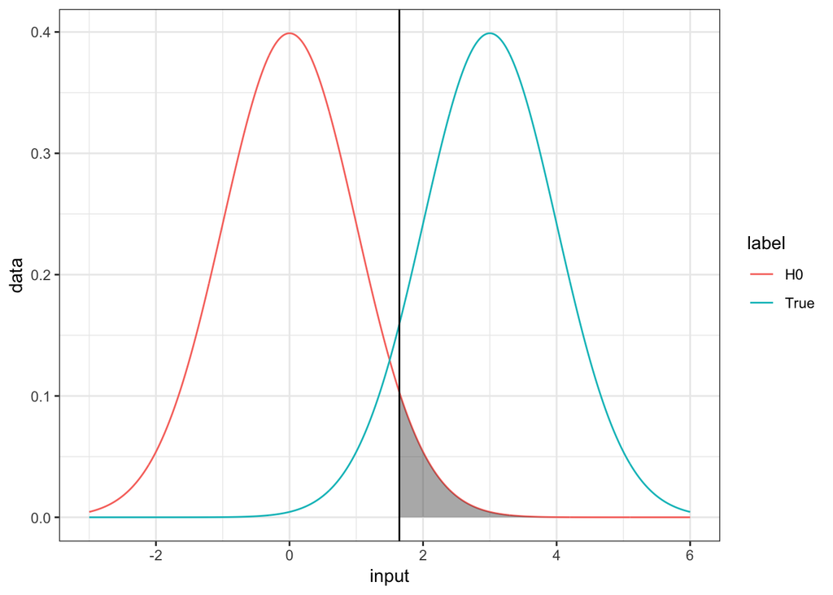

```r
library(ggplot2)

theExercise <- function(sampSize=1000,h0Mean=0, trueMean=3, shadeType="H0",shadeDirection="Right",alpha=0.05){
  splitVal=qnorm(alpha,lower.tail = F)

  input <- seq((h0Mean-3),(3+trueMean),length.out = sampSize)
  x <- dnorm(input,mean = h0Mean)
  y <- dnorm(input,mean = trueMean)
  df <- data.frame(input=c(input,input),data=c(x,y),label=c(rep("H0",sampSize),rep("True",sampSize)))

  thePlot <- ggplot(df,aes(input,data))+
    geom_line(aes(color=label))+
    geom_vline(xintercept = splitVal)+
    theme_bw()

  #DO NOT WORRY ABOUT THIS STUFF! ###############################################
  if(shadeDirection=="Left"){
    shadeMin=-Inf
    shadeMax=splitVal
  }
  if(shadeDirection=="Right"){
    shadeMin=splitVal
    shadeMax=Inf
  }
  hilight <- df[df$input>shadeMin & df$input<shadeMax & df$label==shadeType,]
  hilight$ymin <- rep(0,nrow(hilight))
  thePlot <- thePlot+geom_ribbon(hilight,mapping=aes(x=input,ymin=ymin,ymax=data),alpha=0.4)
  ################################################################################

  thePlot
}

theExercise()
```

Challenge: - Include if statements that will report the area of any region specificed